# Redes Neuronales

Técnicas de aprendizaje de máquina

Oscar Bustos

# Introducción

## Icebreaker: Ciencia Ficción

[figure not shown]

- ¿Cuéntanos cual es tu peli / serie favorita de ciencia ficción?

## Cronograma

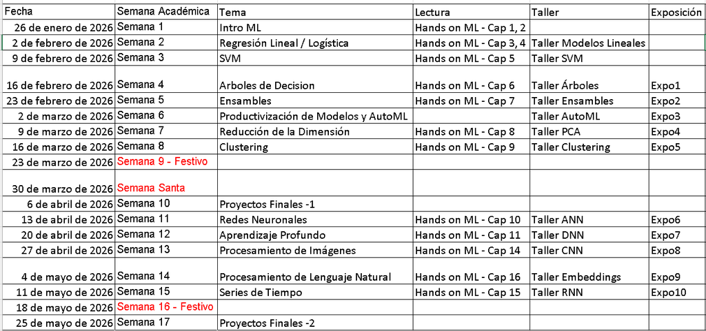

## Capítulos sobre Deep Learning

Capítulo 10

Capítulo 10

## Stacking

Entrenando un modelo que usa como entrada las salidas de otro modelo

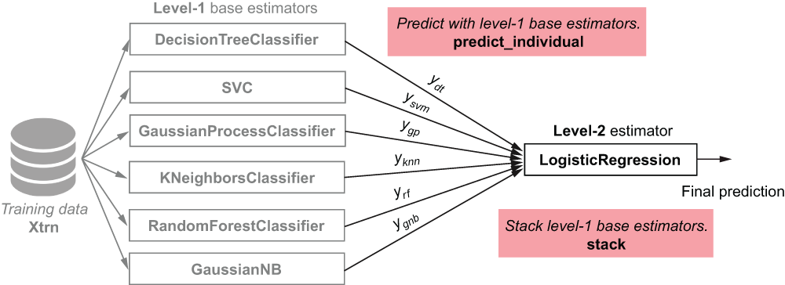

## Inspiración Biológica

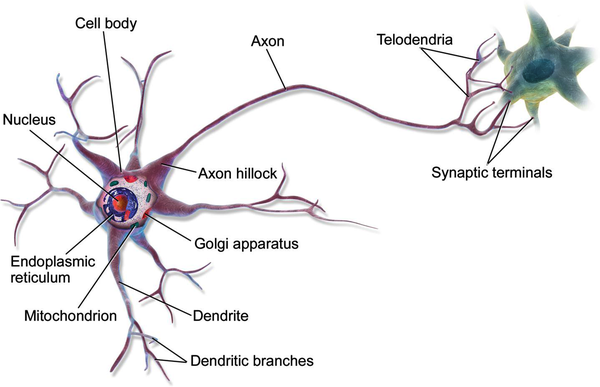

Neurona Biológica

## Inspiración Biológica

[figure not shown]

## Inspiración Biológica

[figure not shown]

Red Neuronal

## Pioneros en Redes Neuronales Artificiales

[figure not shown]

Articulo de Interés: (Rumelhart et al. 1986)

## Juguemos con las Redes Neuronales

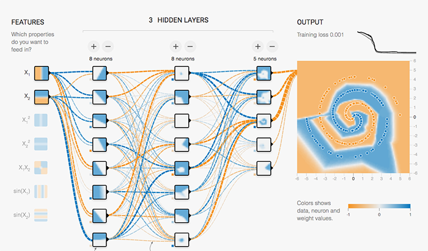

[Understanding neural-networks with tensorflow-playground](https://cloud.google.com/blog/products/ai-machine-learning/understanding-neural-networks-with-tensorflow-playground)

## Zoológico de Redes neuronales

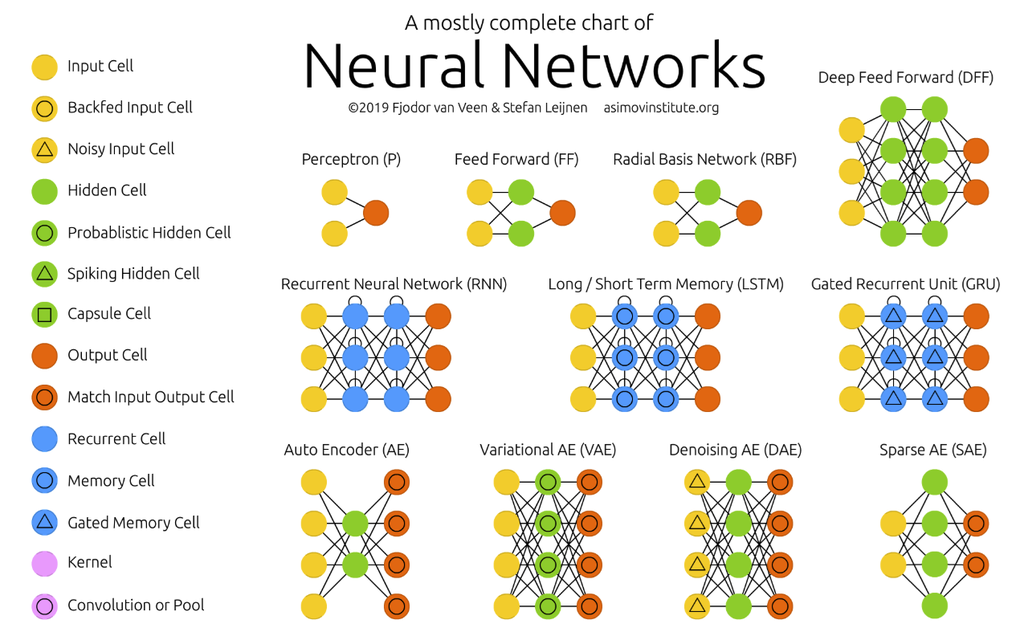

[The Neural Network Zoo](https://www.asimovinstitute.org/neural-network-zoo/)

## Feed Forward Neural Networks (FFNN) y Perceptrones

**Feed Forward Neural Networks**  
Aplicación Ideal: Clasificación y regresión en problemas estructurados. - Reconocimiento de patrones en datos tabulares. - Modelado de funciones complejas. - Aplicaciones en finanzas y predicción de series temporales simples. **Radial Basis Function (RBF) Networks**  
Aplicación Ideal: Problemas de interpolación y aproximación de funciones. - Control adaptativo. - Reconocimiento de caracteres y voz.

## Recurrent Neural Networks (RNN)

**Recurrent Neural Networks (RNN)**  
Aplicación Ideal: Procesamiento de datos secuenciales. - Modelado de lenguaje natural. - Reconocimiento de voz. - Predicción de series temporales. **Long Short-Term Memory (LSTM) Networks**  
Aplicación Ideal: Procesamiento de secuencias largas con dependencias temporales. - Traducción automática. - Generación de texto. - Análisis de sentimientos.

## Recurrent Neural Networks (RNN)

**Recurrent Neural Networks (RNN)**  
Aplicación Ideal: Procesamiento de datos secuenciales. - Modelado de lenguaje natural. - Reconocimiento de voz. - Predicción de series temporales. **Long Short-Term Memory (LSTM) Networks**  
Aplicación Ideal: Procesamiento de secuencias largas con dependencias temporales. - Traducción automática. - Generación de texto. - Análisis de sentimientos.

## Autoencoders (AE)

**Aplicación Ideal:** Reducción de dimensionalidad y detección de anomalías. - Compresión de datos. - Eliminación de ruido en imágenes y señales. - Detección de fraudes.

## Zoológico de Redes neuronales

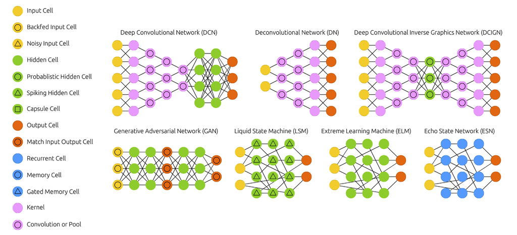

[The Neural Network Zoo](https://www.asimovinstitute.org/neural-network-zoo/)

## Convolutional Neural Networks (CNN)

**Convolutional Neural Networks (CNN)**  
Aplicación Ideal: Procesamiento de imágenes y visión por computadora. - Reconocimiento de objetos y rostros. - Detección de anomalías en imágenes médicas. - Aplicaciones en vehículos autónomos.

**Generative Adversarial Networks (GAN)**  
Aplicación Ideal: Generación de contenido realista. - Creación de imágenes sintéticas. - Restauración y mejora de imágenes. - Generación de música y texto artificial.

## Zoológico de Redes neuronales

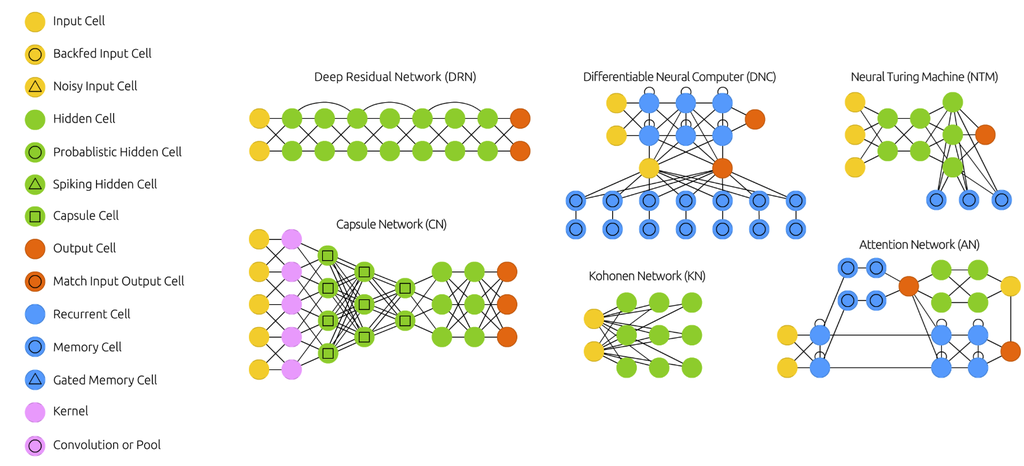

[The Neural Network Zoo](https://www.asimovinstitute.org/neural-network-zoo/)

## Attention Networks (AN)

**Aplicación Ideal:** Modelado de dependencias a largo plazo en datos secuenciales. - Traducción automática con Transformers. - Generación de resúmenes automáticos. - Análisis de documentos extensos. - Base de los Large Language Models (LLM)

# Perceptrón

## Neurona Artificial

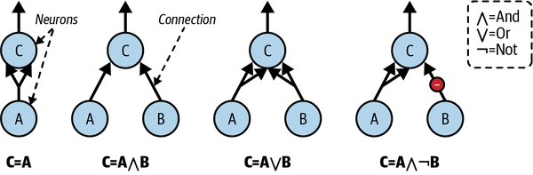

Compuertas Lógicas con Neuronas Artificiales

## Neurona Artificial

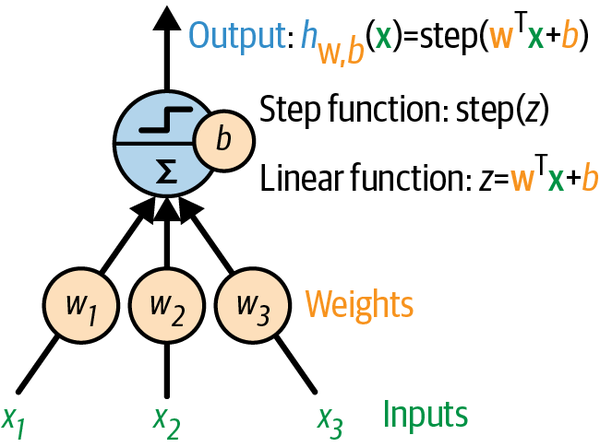

Perceptron con tres entradas y una salida

## Neurona Artificial

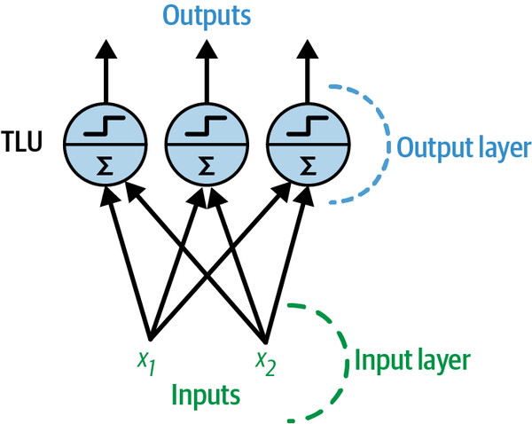

Perceptron con dos entradas y tres salidas

## Neurona Artificial

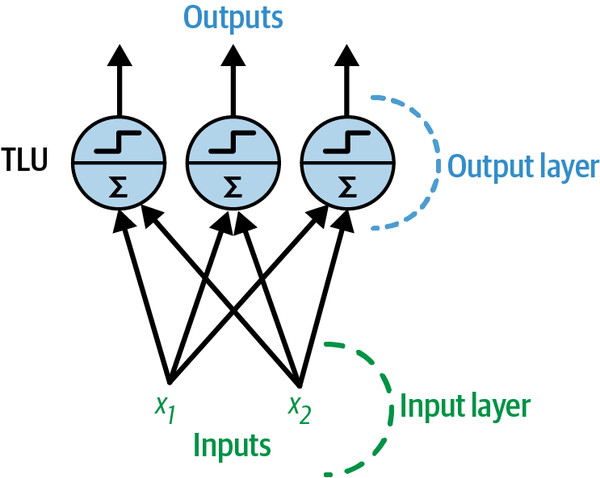

Perceptron con dos entradas y tres salidas

## Modelo Matemático

La Unidad Lógica de Umbral (TLU por sus siglas en inglés *threshold logic unit*) primero calcula una función lineal de sus entradas:
$$\begin{equation}
z = \bm{w}^\top \bm{x} + b
\end{equation}$$
donde: - $\bm{x}$ es el vector de características de entrada. - $\bm{w}$ es el vector de pesos. - $b$ es el término de sesgo. Luego, se aplica una función escalón:
$$\begin{equation}
h_{\bm{w}}(\bm{x}) = \phi(z)
\end{equation}$$
donde: - $\phi(z)$ es la función de activación (función escalón para TLU).

## Tipos de Umbrales

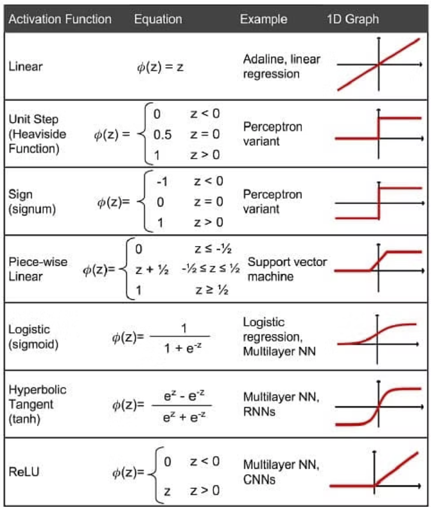

## Regla de Aprendizaje del Perceptrón

La regla de actualización de pesos para el Perceptrón está dada por:
$$\begin{equation}
w_{i,j} \leftarrow w_{i,j} + \eta (y_j - \hat{y}_j) x_i
\end{equation}$$
donde: - $w_{i,j}$ es el peso de conexión entre la $i$-ésima entrada y la $j$-ésima neurona. - $x_i$ es el valor de la $i$-ésima entrada de la instancia de entrenamiento actual. - $\hat{y}_j$ es la salida de la $j$-ésima neurona para la instancia de entrenamiento actual. - $y_j$ es la salida objetivo de la $j$-ésima neurona. - $\eta$ es la tasa de aprendizaje.

## Regla de Aprendizaje del Perceptrón

[figure not shown]

## Problema de optimización

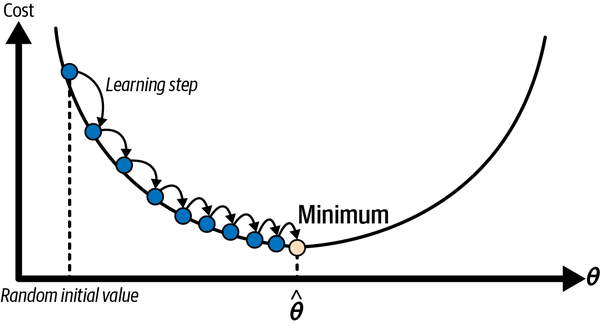

## Problema de optimización

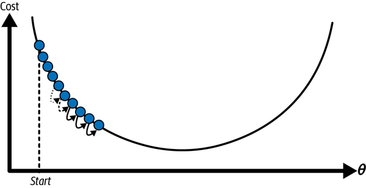

Tasa de aprendizaje muy pequeña

## Problema de optimización

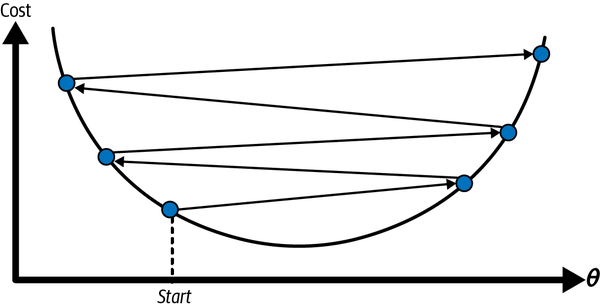

Tasa de aprendizaje muy grande

## Problema de optimización

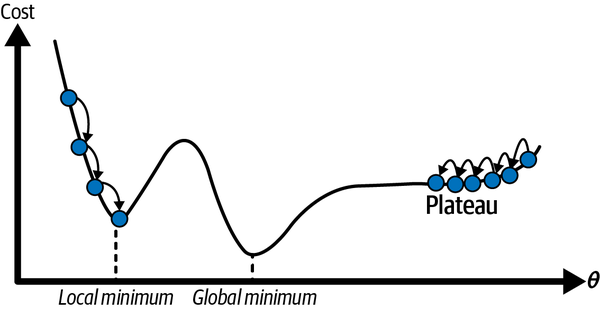

Problema con múltiples mínimos locales y con valles

## Problema de optimización

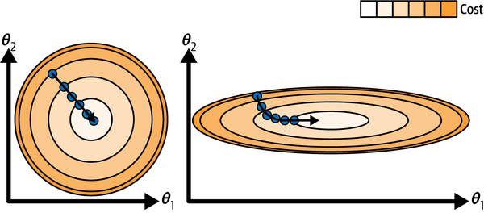

Problema con escalamiento de variables

## Limitaciones del Perceptrón

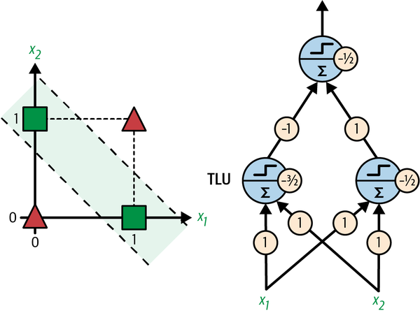

Separación XOR

# Perceptrón Multicapa

## Regiones de decisión para Perceptrones Multicapa

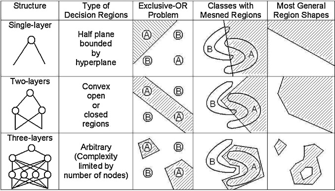

Dependiendo de la arquitectura del perceptron, se pueden resolver problemas convexos

## Arquitectura de un MLP para regresión

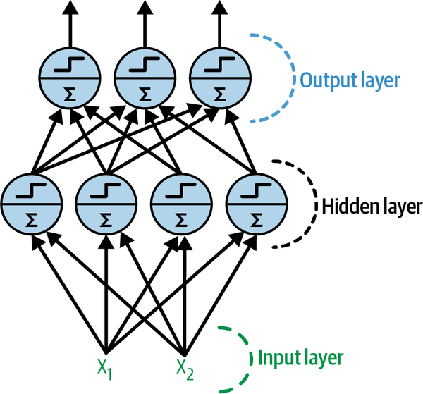

- Capa de entrada: recibe los datos de entrada.
- Capas ocultas: transforman las entradas en representaciones más abstractas.
- Capa de salida: produce la predicción final.

## Arquitectura de un MLP para Clasificación

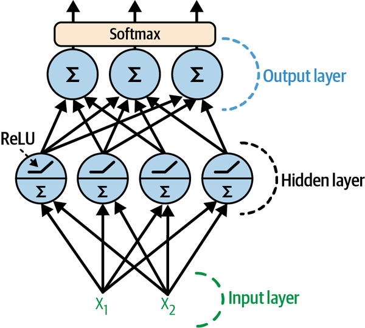

- Capa de entrada: recibe los datos de entrada.
- Capas ocultas: transforman las entradas en representaciones más abstractas.
- Capa de salida: produce la predicción final.

## Funcionamiento de un MLP

1. **Propagación hacia adelante:** Las entradas se propagan a través de la red, capa por capa, hasta la capa de salida.
2. **Cálculo del error:** Se compara la salida de la red con la salida deseada para calcular el error.
3. **Retropropagación:** El error se propaga hacia atrás a través de la red para ajustar los pesos de las conexiones.
4. **Actualización de pesos:** Se utilizan algoritmos de optimización (como el descenso del gradiente) para actualizar los pesos y minimizar el error.

## Entrenamiento de un MLP

- Se utiliza un conjunto de datos de entrenamiento para ajustar los pesos de la red.
- El objetivo es minimizar una función de pérdida que mide la diferencia entre las predicciones de la red y las salidas reales.
- Se utilizan algoritmos de optimización como el descenso del gradiente para encontrar los pesos óptimos.

## Ilustración Retropropagación

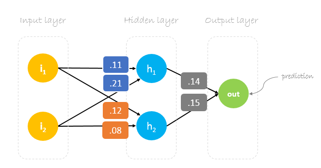

Ejemplo con 1 capa oculta con dos neuronas, dos entradas y una salida